# Homework_10

Claire Kraft

2024-10-27

## Question 14.1

**The breast cancer data set breast-cancer-wisconsin.data.txt from [UCI Repository](http://archive.ics.uci.edu/ml/machine-learning-databases/breast-cancer-wisconsin/) (description at [UCI Dataset Description](http://archive.ics.uci.edu/ml/datasets/Breast+Cancer+Wisconsin+%28Original%29)) has missing values.**

1. **Use the mean/mode imputation method to impute values for the missing data.**
2. **Use regression to impute values for the missing data.**
3. **Use regression with perturbation to impute values for the missing data.**
4. **(Optional) Compare the results and quality of classification models (e.g., SVM, KNN) built using**  
   **(1) the data sets from questions 1, 2, 3;**  
   **(2) the data that remains after data points with missing values are removed;**  
   **(3) the data set when a binary variable is introduced to indicate missing values.**

After performing exploratory data analysis, I imputed the missing values using mean, mode, regression, and regression with perturbation methods.

- For the *mean* imputation, I calculated the mean of the `BareNuclei` column, ignoring the null values, and then replaced the null values with the computations. I repeated the same steps for *mode* imputation.
- For the *regression* imputation, I used the observed values of `BareNuclei` as the dependent variable. The remaining columns became the independent variables. This is a more advanced method, compared to just mean and mode imputations, as it considers the relationship of the dependent and independent variables to impute the missing values [6].
- A drawback of regression imputation is that it does not capture all the variability. *Perturbation* adds variability [2]. The beginning steps of this method are similar to the regression imputation: build the model and predict the missing values. Then I use the `rnorm` function to add “noise” to mimic natural variation. Finally, I replace the missing values with the predictions and noise.

```r
# Library imports
library(tidyverse)
library(data.table)
```

```r
#install.packages("visdat")
library(visdat)
library(ggplot2)
#install.packages("naniar")
library(naniar)
library(GGally) #ggplot2 extension for pairs matrix
#install.packages("psych")
library(psych)
library(rpart)
#install.packages("rpart.plot")
library(rpart.plot)

# Read in data
df <- fread('https://archive.ics.uci.edu/ml/machine-learning-databases/breast-cancer-wisconsin/breast-cancer-wisconsin.data', header=FALSE, stringsAsFactors = FALSE)
# Preview data
head(df)
```

```
##         V1    V2    V3    V4    V5    V6     V7    V8    V9   V10   V11
##      <int> <int> <int> <int> <int> <int> <char> <int> <int> <int> <int>
## 1: 1000025     5     1     1     1     2      1     3     1     1     2
## 2: 1002945     5     4     4     5     7     10     3     2     1     2
## 3: 1015425     3     1     1     1     2      2     3     1     1     2
## 4: 1016277     6     8     8     1     3      4     3     7     1     2
## 5: 1017023     4     1     1     3     2      1     3     1     1     2
## 6: 1017122     8    10    10     8     7     10     9     7     1     4
```

```r
summary(df)
```

```
##        V1                 V2               V3               V4
##  Min.   :   61634   Min.   : 1.000   Min.   : 1.000   Min.   : 1.000
##  1st Qu.:  870688   1st Qu.: 2.000   1st Qu.: 1.000   1st Qu.: 1.000
##  Median : 1171710   Median : 4.000   Median : 1.000   Median : 1.000
##  Mean   : 1071704   Mean   : 4.418   Mean   : 3.134   Mean   : 3.207
##  3rd Qu.: 1238298   3rd Qu.: 6.000   3rd Qu.: 5.000   3rd Qu.: 5.000
##  Max.   :13454352   Max.   :10.000   Max.   :10.000   Max.   :10.000
##        V5               V6              V7                  V8
##  Min.   : 1.000   Min.   : 1.000   Length:699         Min.   : 1.000
##  1st Qu.: 1.000   1st Qu.: 2.000   Class :character   1st Qu.: 2.000
##  Median : 1.000   Median : 2.000   Mode  :character   Median : 3.000
##  Mean   : 2.807   Mean   : 3.216                      Mean   : 3.438
##  3rd Qu.: 4.000   3rd Qu.: 4.000                      3rd Qu.: 5.000
##  Max.   :10.000   Max.   :10.000                      Max.   :10.000
##        V9              V10              V11
##  Min.   : 1.000   Min.   : 1.000   Min.   :2.00
##  1st Qu.: 1.000   1st Qu.: 1.000   1st Qu.:2.00
##  Median : 1.000   Median : 1.000   Median :2.00
##  Mean   : 2.867   Mean   : 1.589   Mean   :2.69
##  3rd Qu.: 4.000   3rd Qu.: 1.000   3rd Qu.:4.00
##  Max.   :10.000   Max.   :10.000   Max.   :4.00
```

```r
# Count observations per class
df %>%
  count(V11)
```

```
##      V11     n
##    <int> <int>
## 1:     2   458
## 2:     4   241
```

```r
# Copy original df
df_cleaning <- df

# Rename columns
df_cleaning <- rename (df_cleaning,
                       SampleCode=V1,
                       ClumpThickness=V2,
                       CellSize=V3,
                       CellShape=V4,
                       Adhesion=V5,
                       SingleEpithelialSize=V6,
                       BareNuclei=V7,
                       BlandChromatin=V8,
                       NormalNucleoli=V9,
                       Mitoses=V10,
                       Diagnosis=V11)

# Convert BareNuclei or V7 column to integer
df_cleaning$BareNuclei <- as.integer(df_cleaning$BareNuclei)
# Convert Diagnosis or V11 to factor
df_cleaning$Diagnosis <- as.factor(df_cleaning$Diagnosis)

# Set the levels of the Diagnosis factor to 0 and 1. This effectively assigns new labels to the existing factor levels.
levels(df_cleaning$Diagnosis) <- c(0, 1)

summary(df_cleaning)
```

```
##    SampleCode       ClumpThickness      CellSize        CellShape
##  Min.   :   61634   Min.   : 1.000   Min.   : 1.000   Min.   : 1.000
##  1st Qu.:  870688   1st Qu.: 2.000   1st Qu.: 1.000   1st Qu.: 1.000
##  Median : 1171710   Median : 4.000   Median : 1.000   Median : 1.000
##  Mean   : 1071704   Mean   : 4.418   Mean   : 3.134   Mean   : 3.207
##  3rd Qu.: 1238298   3rd Qu.: 6.000   3rd Qu.: 5.000   3rd Qu.: 5.000
##  Max.   :13454352   Max.   :10.000   Max.   :10.000   Max.   :10.000
##
##     Adhesion      SingleEpithelialSize   BareNuclei     BlandChromatin
##  Min.   : 1.000   Min.   : 1.000       Min.   : 1.000   Min.   : 1.000
##  1st Qu.: 1.000   1st Qu.: 2.000       1st Qu.: 1.000   1st Qu.: 2.000
##  Median : 1.000   Median : 2.000       Median : 1.000   Median : 3.000
##  Mean   : 2.807   Mean   : 3.216       Mean   : 3.545   Mean   : 3.438
##  3rd Qu.: 4.000   3rd Qu.: 4.000       3rd Qu.: 6.000   3rd Qu.: 5.000
##  Max.   :10.000   Max.   :10.000       Max.   :10.000   Max.   :10.000
##                                        NA's   :16
##  NormalNucleoli      Mitoses       Diagnosis
##  Min.   : 1.000   Min.   : 1.000   0:458
##  1st Qu.: 1.000   1st Qu.: 1.000   1:241
##  Median : 1.000   Median : 1.000
##  Mean   : 2.867   Mean   : 1.589
##  3rd Qu.: 4.000   3rd Qu.: 1.000
##  Max.   :10.000   Max.   :10.000
##
```

```r
head(df_cleaning)
```

```
##    SampleCode ClumpThickness CellSize CellShape Adhesion SingleEpithelialSize
##         <int>          <int>    <int>     <int>    <int>                <int>
## 1:    1000025              5        1         1        1                    2
## 2:    1002945              5        4         4        5                    7
## 3:    1015425              3        1         1        1                    2
## 4:    1016277              6        8         8        1                    3
## 5:    1017023              4        1         1        3                    2
## 6:    1017122              8       10        10        8                    7
##    BareNuclei BlandChromatin NormalNucleoli Mitoses Diagnosis
##         <int>          <int>          <int>   <int>    <fctr>
## 1:          1              3              1       1         0
## 2:         10              3              2       1         0
## 3:          2              3              1       1         0
## 4:          4              3              7       1         0
## 5:          1              3              1       1         0
## 6:         10              9              7       1         1
```

```r
# Dupes check
n_distinct(df_cleaning)
```

```
## [1] 691
```

```r
# Zoom in on the dupes
duplicates <- df_cleaning %>%
  filter(duplicated(.))

print(duplicates)
```

```
##    SampleCode ClumpThickness CellSize CellShape Adhesion SingleEpithelialSize
##         <int>          <int>    <int>     <int>    <int>                <int>
## 1:    1218860              1        1         1        1                    1
## 2:    1100524              6       10        10        2                    8
## 3:    1116116              9       10        10        1                   10
## 4:    1198641              3        1         1        1                    2
## 5:     320675              3        3         5        2                    3
## 6:     704097              1        1         1        1                    1
## 7:    1321942              5        1         1        1                    2
## 8:     466906              1        1         1        1                    2
##    BareNuclei BlandChromatin NormalNucleoli Mitoses Diagnosis
##         <int>          <int>          <int>   <int>    <fctr>
## 1:          1              3              1       1         0
## 2:         10              7              3       3         1
## 3:          8              3              3       1         1
## 4:          1              3              1       1         0
## 5:         10              7              1       1         1
## 6:          1              2              1       1         0
## 7:          1              3              1       1         0
## 8:          1              1              1       1         0
```

```r
missing_col_summary <- colSums(is.na(df_cleaning))
print(missing_col_summary)
```

```
##           SampleCode       ClumpThickness             CellSize
##                    0                    0                    0
##            CellShape             Adhesion SingleEpithelialSize
##                    0                    0                    0
##           BareNuclei       BlandChromatin       NormalNucleoli
##                   16                    0                    0
##              Mitoses            Diagnosis
##                    0                    0
```

```r
print(sprintf("Percent of missing observation = %0.3f", 16/nrow(df_cleaning)*100))
```

```
## [1] "Percent of missing observation = 2.289"
```

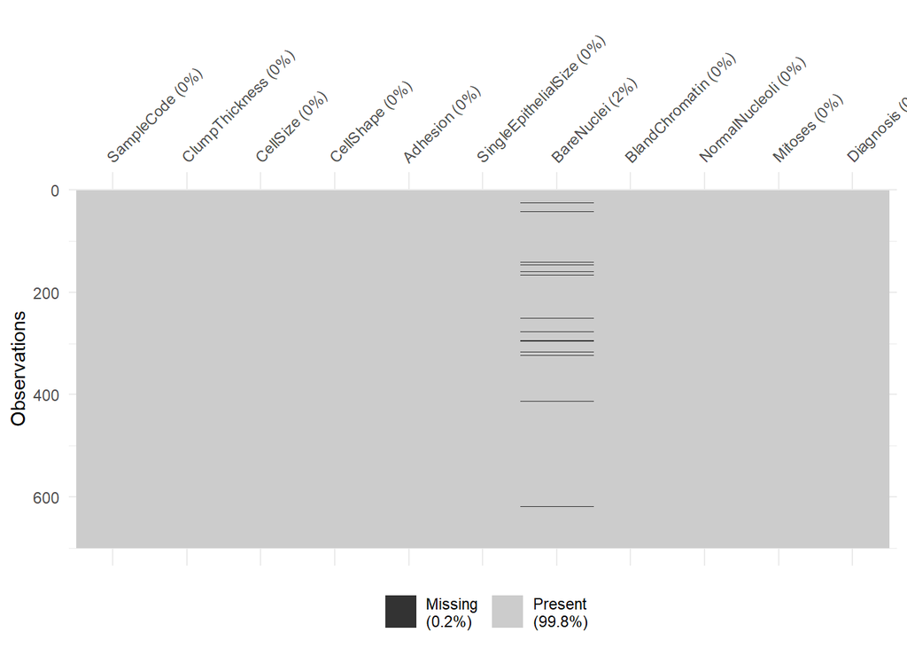

```r
# Visualize missing values
vis_miss(df_cleaning)
```

```r
# Look at reference 4
# Correlation viz
df_cleaning_x <- select_if(df_cleaning, is.numeric)
cor(df_cleaning_x)
```

```
##                       SampleCode ClumpThickness    CellSize   CellShape
## SampleCode            1.00000000    -0.05530844 -0.04160334 -0.04157607
## ClumpThickness       -0.05530844     1.00000000  0.64491250  0.65458908
## CellSize             -0.04160334     0.64491250  1.00000000  0.90688191
## CellShape            -0.04157607     0.65458908  0.90688191  1.00000000
## Adhesion             -0.06487808     0.48635624  0.70558181  0.68307920
## SingleEpithelialSize -0.04552828     0.52181622  0.75179913  0.71966844
## BareNuclei                    NA             NA          NA          NA
## BlandChromatin       -0.06005053     0.55842816  0.75572098  0.73594845
## NormalNucleoli       -0.05207195     0.53583455  0.72286482  0.71944632
## Mitoses              -0.03490066     0.35003386  0.45869315  0.43891093
##                         Adhesion SingleEpithelialSize BareNuclei BlandChromatin
## SampleCode           -0.06487808          -0.04552828         NA    -0.06005053
## ClumpThickness        0.48635624           0.52181622         NA     0.55842816
## CellSize              0.70558181           0.75179913         NA     0.75572098
## CellShape             0.68307920           0.71966844         NA     0.73594845
## Adhesion              1.00000000           0.59959907         NA     0.66671533
## SingleEpithelialSize  0.59959907           1.00000000         NA     0.61610184
## BareNuclei                    NA                   NA          1             NA
## BlandChromatin        0.66671533           0.61610184         NA     1.00000000
## NormalNucleoli        0.60335241           0.62888069         NA     0.66587781
## Mitoses               0.41763278           0.47910148         NA     0.34416950
##                      NormalNucleoli     Mitoses
## SampleCode              -0.05207195 -0.03490066
## ClumpThickness           0.53583455  0.35003386
## CellSize                 0.72286482  0.45869315
## CellShape                0.71944632  0.43891093
## Adhesion                 0.60335241  0.41763278
## SingleEpithelialSize     0.62888069  0.47910148
## BareNuclei                       NA          NA
## BlandChromatin           0.66587781  0.34416950
## NormalNucleoli           1.00000000  0.42833575
## Mitoses                  0.42833575  1.00000000
```

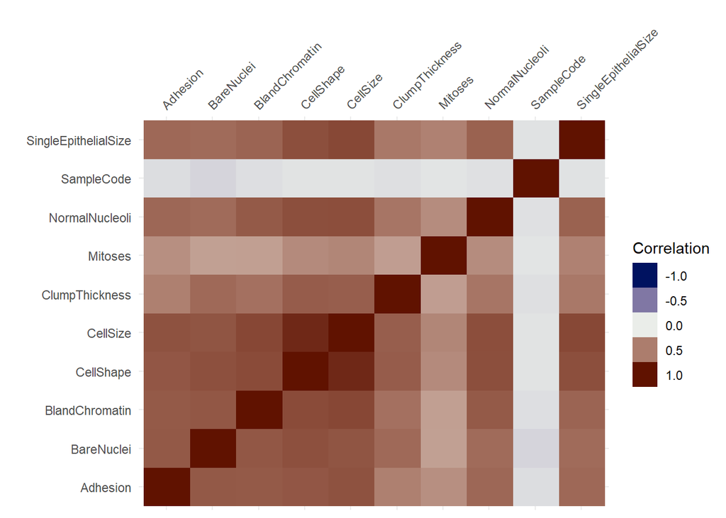

```r
vis_cor(df_cleaning_x)
```

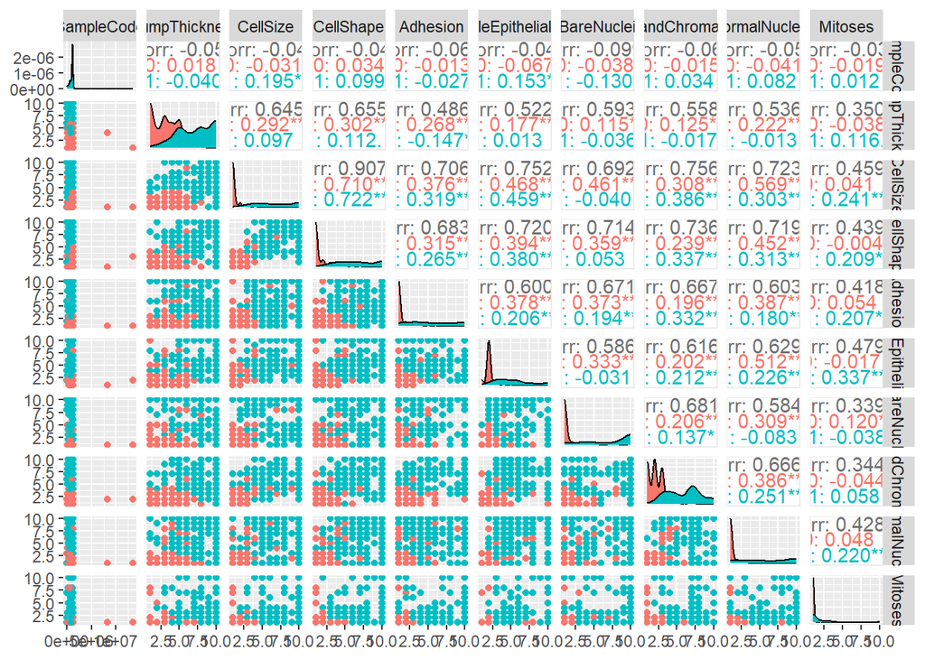

```r
# Change Diagnosis from integer to factor
df_cleaning$Diagnosis <- as.factor(df_cleaning$Diagnosis)

pairwise <- ggpairs(df_cleaning, columns = 1:10, ggplot2::aes(colour = Diagnosis), lower=list(combo=wrap("facethist", binwidth=0.5)))
pairwise
```

```r
# Look at reference 4
skew(df_cleaning_x)
```

```
##  [1] 13.6166895  0.5903165  1.2278492  1.1568774  1.5179315  1.7048304
##  [7]  0.9856714  1.0952527  1.4161630  3.5453906
```

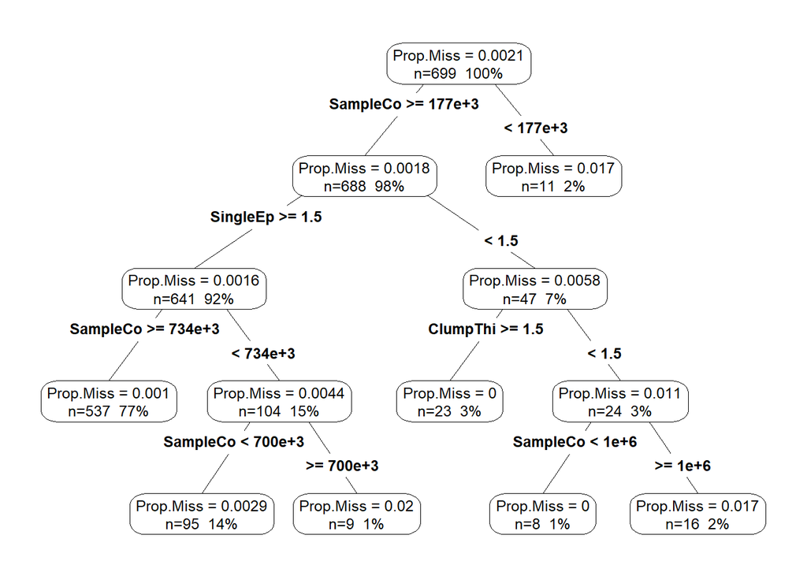

```r
df_cleaning %>%
  add_prop_miss() %>%
  rpart(prop_miss_all ~ ., data=.) %>%
  prp(type=4, extra = 101, roundint=FALSE, prefix="Prop.Miss = ")
```

### Imputation - mean/mode

```r
#---------------------- Mean imputation
df_cleaning.mean<-df_cleaning
df_cleaning.mean<-df_cleaning.mean %>% mutate_at(vars(BareNuclei),~ifelse(is.na(.x), mean(.x, na.rm = TRUE), .x))

# Double check mean imputation
head(df_cleaning.mean,24)
```

```
##     SampleCode ClumpThickness CellSize CellShape Adhesion SingleEpithelialSize
##          <int>          <int>    <int>     <int>    <int>                <int>
##  1:    1000025              5        1         1        1                    2
##  2:    1002945              5        4         4        5                    7
##  3:    1015425              3        1         1        1                    2
##  4:    1016277              6        8         8        1                    3
##  5:    1017023              4        1         1        3                    2
##  6:    1017122              8       10        10        8                    7
##  7:    1018099              1        1         1        1                    2
##  8:    1018561              2        1         2        1                    2
##  9:    1033078              2        1         1        1                    2
## 10:    1033078              4        2         1        1                    2
## 11:    1035283              1        1         1        1                    1
## 12:    1036172              2        1         1        1                    2
## 13:    1041801              5        3         3        3                    2
```

[output cut: 39 more lines]

```r
#---------------------- Mode imputation
# Find mode - look at reference 3
getmode <- function(v) {
   uniqv <- unique(v)
   uniqv[which.max(tabulate(match(v, uniqv)))]
}

df_cleaning.mode<-df_cleaning
mode.result <- getmode(df_cleaning.mode$BareNuclei)
print(mode.result)
```

```
## [1] 1
```

```r
# Fill NAs with mode of 1s
df_cleaning.mode$BareNuclei[is.na(df_cleaning.mode$BareNuclei)] <- mode.result

# Double check mode imputation
head(df_cleaning.mode,24)
```

```
##     SampleCode ClumpThickness CellSize CellShape Adhesion SingleEpithelialSize
##          <int>          <int>    <int>     <int>    <int>                <int>
##  1:    1000025              5        1         1        1                    2
##  2:    1002945              5        4         4        5                    7
##  3:    1015425              3        1         1        1                    2
##  4:    1016277              6        8         8        1                    3
##  5:    1017023              4        1         1        3                    2
##  6:    1017122              8       10        10        8                    7
##  7:    1018099              1        1         1        1                    2
##  8:    1018561              2        1         2        1                    2
##  9:    1033078              2        1         1        1                    2
## 10:    1033078              4        2         1        1                    2
## 11:    1035283              1        1         1        1                    1
## 12:    1036172              2        1         1        1                    2
## 13:    1041801              5        3         3        3                    2
```

[output cut: 39 more lines]

### Imputation - regression

#### Explanation:

1. **Identify Missing Values**:
   - `missing.index <- which(is.na(reg_df$BareNuclei), arr.ind=TRUE)`: Finds the indices of missing values in the `BareNuclei` column.
2. **Remove Rows with Missing Values**:
   - `reg_df.1 <- reg_df[-missing.index, 2:10]`: Removes rows with missing `BareNuclei` values and considers only columns 2 to 10 for regression.
3. **Fit Regression Model**:
   - `reg_model <- lm(BareNuclei ~ ClumpThickness + CellSize + CellShape + Adhesion + SingleEpithelialSize + BlandChromatin + NormalNucleoli + Mitoses, data = reg_df.1)`: Fits a linear regression model to predict `BareNuclei` based on other variables.
4. **Predict Missing Values**:
   - `predicted_values <- predict(reg_model, reg_df[missing.index, 2:10])`: Uses the fitted model to predict missing `BareNuclei` values.
5. **Impute Predicted Values**:
   - `reg_df$BareNuclei[missing.index] <- predicted_values`: Replaces the missing values in the `BareNuclei` column with the predicted values.
6. **Check Imputation**:
   - `summary(reg_df)`: Provides a summary of the dataframe after imputation to verify the changes.

```r
# For reproducibility
set.seed(123)

# Make a copy of the dataframe to preserve the original data
reg_df <- df_cleaning

# Identify the indices of missing values in the BareNuclei column
missing.index <- which(is.na(reg_df$BareNuclei), arr.ind=TRUE)

# Remove rows with missing BareNuclei values from the dataframe
reg_df.1 <- reg_df[-missing.index, 2:10]

# Fit a linear regression model to predict BareNuclei using other columns
reg_model <- lm(BareNuclei ~ ClumpThickness + CellSize + CellShape + Adhesion +
                SingleEpithelialSize + BlandChromatin + NormalNucleoli + Mitoses, data = reg_df.1)
summary(reg_model)
```

```
##
## Call:
## lm(formula = BareNuclei ~ ClumpThickness + CellSize + CellShape +
##     Adhesion + SingleEpithelialSize + BlandChromatin + NormalNucleoli +
##     Mitoses, data = reg_df.1)
##
## Residuals:
##     Min      1Q  Median      3Q     Max
## -9.7316 -0.9426 -0.3002  0.6725  8.6998
##
## Coefficients:
##                       Estimate Std. Error t value Pr(>|t|)
## (Intercept)          -0.616652   0.194975  -3.163  0.00163 **
## ClumpThickness        0.230156   0.041691   5.521 4.83e-08 ***
## CellSize             -0.067980   0.076170  -0.892  0.37246
## CellShape             0.340442   0.073420   4.637 4.25e-06 ***
## Adhesion              0.339705   0.045919   7.398 4.13e-13 ***
## SingleEpithelialSize  0.090392   0.062541   1.445  0.14883
## BlandChromatin        0.320577   0.059047   5.429 7.91e-08 ***
## NormalNucleoli        0.007293   0.044486   0.164  0.86983
## Mitoses              -0.075230   0.059331  -1.268  0.20524
## ---
## Signif. codes:  0 '***' 0.001 '**' 0.01 '*' 0.05 '.' 0.1 ' ' 1
##
## Residual standard error: 2.274 on 674 degrees of freedom
## Multiple R-squared:  0.615,  Adjusted R-squared:  0.6104
## F-statistic: 134.6 on 8 and 674 DF,  p-value: < 2.2e-16
```

```r
# Use the fitted model to predict missing BareNuclei values
predicted_values <- predict(reg_model, reg_df[missing.index, 2:10])

# Impute the predicted values back into the original dataframe
reg_df$BareNuclei[missing.index] <- predicted_values

# Check the dataframe after imputation
summary(reg_df)
```

```
##    SampleCode       ClumpThickness      CellSize        CellShape
##  Min.   :   61634   Min.   : 1.000   Min.   : 1.000   Min.   : 1.000
##  1st Qu.:  870688   1st Qu.: 2.000   1st Qu.: 1.000   1st Qu.: 1.000
##  Median : 1171710   Median : 4.000   Median : 1.000   Median : 1.000
##  Mean   : 1071704   Mean   : 4.418   Mean   : 3.134   Mean   : 3.207
##  3rd Qu.: 1238298   3rd Qu.: 6.000   3rd Qu.: 5.000   3rd Qu.: 5.000
##  Max.   :13454352   Max.   :10.000   Max.   :10.000   Max.   :10.000
##     Adhesion      SingleEpithelialSize   BareNuclei      BlandChromatin
##  Min.   : 1.000   Min.   : 1.000       Min.   : 0.5687   Min.   : 1.000
##  1st Qu.: 1.000   1st Qu.: 2.000       1st Qu.: 1.0000   1st Qu.: 2.000
##  Median : 1.000   Median : 2.000       Median : 1.0000   Median : 3.000
##  Mean   : 2.807   Mean   : 3.216       Mean   : 3.5266   Mean   : 3.438
##  3rd Qu.: 4.000   3rd Qu.: 4.000       3rd Qu.: 5.9230   3rd Qu.: 5.000
##  Max.   :10.000   Max.   :10.000       Max.   :10.0000   Max.   :10.000
##  NormalNucleoli      Mitoses       Diagnosis
##  Min.   : 1.000   Min.   : 1.000   0:458
##  1st Qu.: 1.000   1st Qu.: 1.000   1:241
##  Median : 1.000   Median : 1.000
##  Mean   : 2.867   Mean   : 1.589
##  3rd Qu.: 4.000   3rd Qu.: 1.000
##  Max.   :10.000   Max.   :10.000
```

### Imputation - perturbation

#### Explanation:

1. **Calculate Residuals and Noise Level**:
   - Get residuals from the regression model and calculate the standard deviation to set the noise level.
2. **Add Noise to Predictions**:
   - Use `rnorm` to add random noise to the predicted values.
3. **Impute Perturbed Values**:
   - Replace the missing values with these perturbed predictions.

```r
# For reproducibility
set.seed(123)

# Make a copy of the dataframe to preserve the original data
perturbation_df <- df_cleaning

# Identify the indices of missing values in the BareNuclei column
missing.index <- which(is.na(perturbation_df$BareNuclei), arr.ind=TRUE)

# Remove rows with missing BareNuclei values from the dataframe
perturbation_df.1 <- perturbation_df[-missing.index, 2:10]

# Fit a linear regression model to predict BareNuclei using other columns
reg_model <- lm(BareNuclei ~ ClumpThickness + CellSize + CellShape + Adhesion +
                SingleEpithelialSize + BlandChromatin + NormalNucleoli + Mitoses, data = perturbation_df.1)
summary(reg_model)
```

```
##
## Call:
## lm(formula = BareNuclei ~ ClumpThickness + CellSize + CellShape +
##     Adhesion + SingleEpithelialSize + BlandChromatin + NormalNucleoli +
##     Mitoses, data = perturbation_df.1)
##
## Residuals:
##     Min      1Q  Median      3Q     Max
## -9.7316 -0.9426 -0.3002  0.6725  8.6998
##
## Coefficients:
##                       Estimate Std. Error t value Pr(>|t|)
## (Intercept)          -0.616652   0.194975  -3.163  0.00163 **
## ClumpThickness        0.230156   0.041691   5.521 4.83e-08 ***
## CellSize             -0.067980   0.076170  -0.892  0.37246
## CellShape             0.340442   0.073420   4.637 4.25e-06 ***
## Adhesion              0.339705   0.045919   7.398 4.13e-13 ***
## SingleEpithelialSize  0.090392   0.062541   1.445  0.14883
## BlandChromatin        0.320577   0.059047   5.429 7.91e-08 ***
## NormalNucleoli        0.007293   0.044486   0.164  0.86983
## Mitoses              -0.075230   0.059331  -1.268  0.20524
## ---
## Signif. codes:  0 '***' 0.001 '**' 0.01 '*' 0.05 '.' 0.1 ' ' 1
##
## Residual standard error: 2.274 on 674 degrees of freedom
## Multiple R-squared:  0.615,  Adjusted R-squared:  0.6104
## F-statistic: 134.6 on 8 and 674 DF,  p-value: < 2.2e-16
```

```r
# Use the fitted model to predict missing BareNuclei values
predicted_values <- predict(reg_model, perturbation_df[missing.index, 2:10])

# Add some random noise (perturbation) to the predicted values
# Using standard deviation of residuals as noise level
residuals <- residuals(reg_model)
noise_level <- sd(residuals)
perturbed_values <- predicted_values + rnorm(length(predicted_values), mean = 0, sd = noise_level)

# Impute the perturbed values back into the original dataframe
perturbation_df$BareNuclei[missing.index] <- perturbed_values

# Check the dataframe after imputation
summary(perturbation_df)
```

```
##    SampleCode       ClumpThickness      CellSize        CellShape
##  Min.   :   61634   Min.   : 1.000   Min.   : 1.000   Min.   : 1.000
##  1st Qu.:  870688   1st Qu.: 2.000   1st Qu.: 1.000   1st Qu.: 1.000
##  Median : 1171710   Median : 4.000   Median : 1.000   Median : 1.000
##  Mean   : 1071704   Mean   : 4.418   Mean   : 3.134   Mean   : 3.207
##  3rd Qu.: 1238298   3rd Qu.: 6.000   3rd Qu.: 5.000   3rd Qu.: 5.000
##  Max.   :13454352   Max.   :10.000   Max.   :10.000   Max.   :10.000
##     Adhesion      SingleEpithelialSize   BareNuclei    BlandChromatin
##  Min.   : 1.000   Min.   : 1.000       Min.   :-1.10   Min.   : 1.000
##  1st Qu.: 1.000   1st Qu.: 2.000       1st Qu.: 1.00   1st Qu.: 2.000
##  Median : 1.000   Median : 2.000       Median : 1.00   Median : 3.000
##  Mean   : 2.807   Mean   : 3.216       Mean   : 3.54   Mean   : 3.438
##  3rd Qu.: 4.000   3rd Qu.: 4.000       3rd Qu.: 6.00   3rd Qu.: 5.000
##  Max.   :10.000   Max.   :10.000       Max.   :10.00   Max.   :10.000
##  NormalNucleoli      Mitoses       Diagnosis
##  Min.   : 1.000   Min.   : 1.000   0:458
##  1st Qu.: 1.000   1st Qu.: 1.000   1:241
##  Median : 1.000   Median : 1.000
##  Mean   : 2.867   Mean   : 1.589
##  3rd Qu.: 4.000   3rd Qu.: 1.000
##  Max.   :10.000   Max.   :10.000
```

## Question 15.1

**Describe a situation or problem from your job, everyday life, current events, etc., for which optimization would be appropriate. What data would you need?**

Optimization is used in descriptive and predictive analytics [1] and there are three parts to it - variables, constraints, and objective function [2]. In November I will be supporting my sister in the NYC Marathon. Applying these three parts to my NYC Marathon cheering strategy, the goal or *objective function* is to maximize the number of times I can cheer her without missing her. The key *variables* are the mile markers (where I can stand and cheer). *Constraints* include traffic, public transportation schedules, and crowd density, which can all affect my adherence to my cheering strategy.

References:

[1] Lecture 1 slides

[2] Lecture 3 slides

[3] R - Mean, Median and Mode - Tutorialspoint. (2019). Tutorialspoint.com. https://www.tutorialspoint.com/r/r_mean_median_mode.htm

[4] RPubs - Vaar R Notebook: Breast Cancer Wisconsin Original. (2023, August 12). Rpubs.com. https://rpubs.com/bi23le/1070975

[5] Microsoft. (2024). Copilot: AI companion. Accessed 2024-10-27. Prompt: ‘Add comments to my lines of code.’ Generated using https://www.microsoft.com.”

[5] Microsoft. (2024). Copilot: AI companion. Accessed 2024-10-29. Prompt: ‘Here’s my code, read it, understand it, then write a concise explanation the steps in rmd format.’ Generated using https://www.microsoft.com.”

[6] Learn how to fill in missing values for regression analysis using different imputation methods and R. Compare the advantages and disadvantages of each method. (2023, September 27). Linkedin.com. https://www.linkedin.com/advice/0/how-can-you-impute-missing-data-regression-analysis